# Racial prejudice and stereotypes (Meta-Results from 4 Studies)

Kyle Peyton

8/3/2018

# Stereotype endorsement

### Work ethic

Question wording: “A score of 1 means you think almost all people in that group are”hardworking" and a score of 7 means you think all people in that group are “lazy”. A score of 4 means you think the group is not towards one end or the other, and of course you may choose any number in between."

The plot below shows the means and 90% confidence intervals, faceted by the respondent’s own group identity. Responses are re-coded so that higher values indicate higher levels of perceived work-ethic.

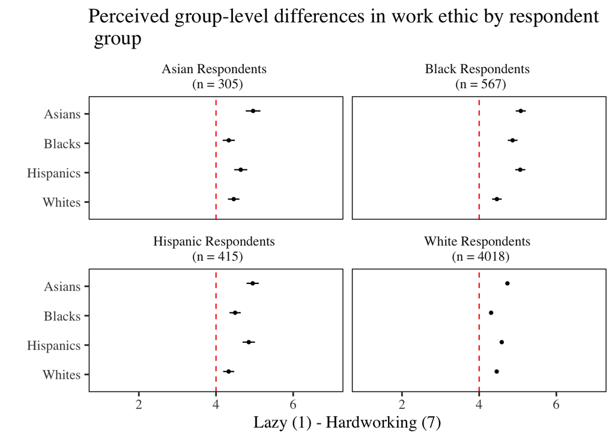

### Intelligence

Question wording: “A score of 1 means you think almost all people in that group are”intelligent" and a score of 7 means you think all people in that group are “unintelligent”. A score of 4 means you think the group is not towards one end or the other, and of course you may choose any number in between."

Responses are re-coded so that higher values indicate higher levels of perceived intelligence. The results with 90% confidence intervals are plotted below.

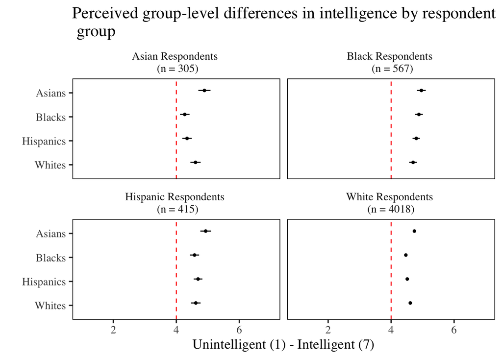

### Trustworthiness

Question wording: “A score of 1 means you think almost all people in that group are”untrustworthy" and a score of 7 means you think all people in that group are “trustworthy”. A score of 4 means you think the group is not towards one end or the other, and of course you may choose any number in between."

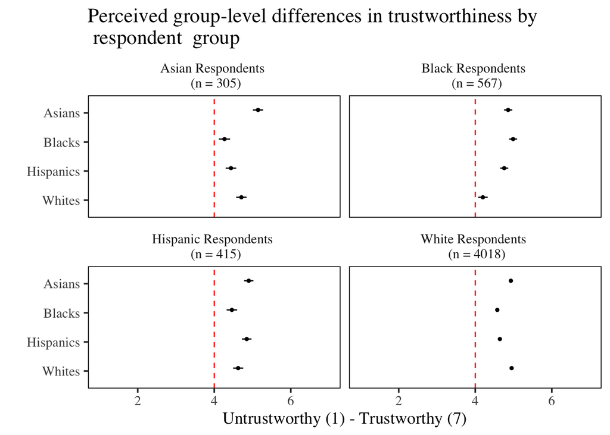

### Aggression

Question wording: “A score of 1 means you think almost all people in that group are”violent" and a score of 7 means you think all people in that group are “peaceful”. A score of 4 means you think the group is not towards one end or the other, and of course you may choose any number in between."

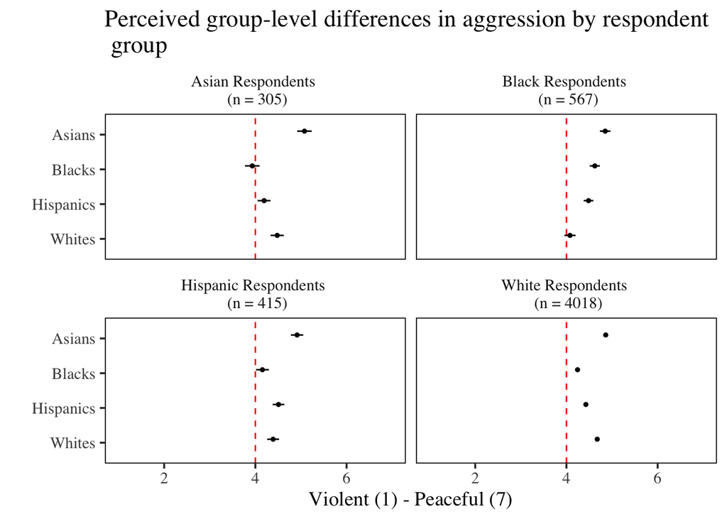

# Overt racism

Now I compute a measure of overt racism, focusing specifically on anti-black prejudice. First, I focus simply on perceived group differences between blacks and whites by subtracting each respondent’s “laziness” rating for blacks from the corresponding laziness rating for whites. For each trait, a positive score indicates the respondent ranked blacks as inferior to whites.

Next, for each respondent, I take the difference between their evaluation of blacks as a group, and their own group on each of the four stereotype dimensions explored above. Each respondent then receives a score that correspondens to their belief in their own group’s superiority over “blacks”. For example, for asian respondents, this is the extent to which they believe blacks as a group are inferior to asians with respect to work ethic, trustworthiness, etc.

### Work ethic

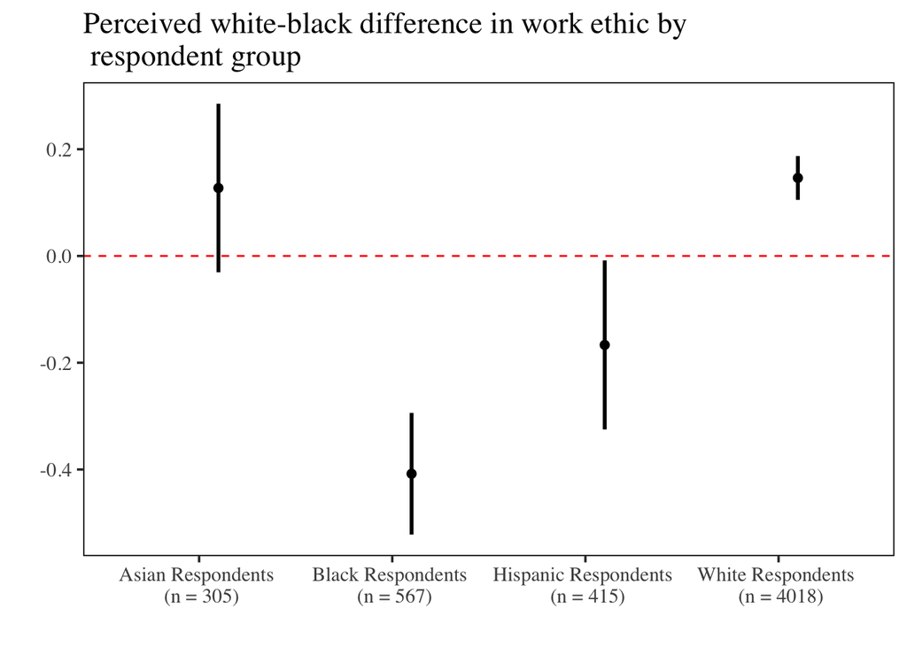

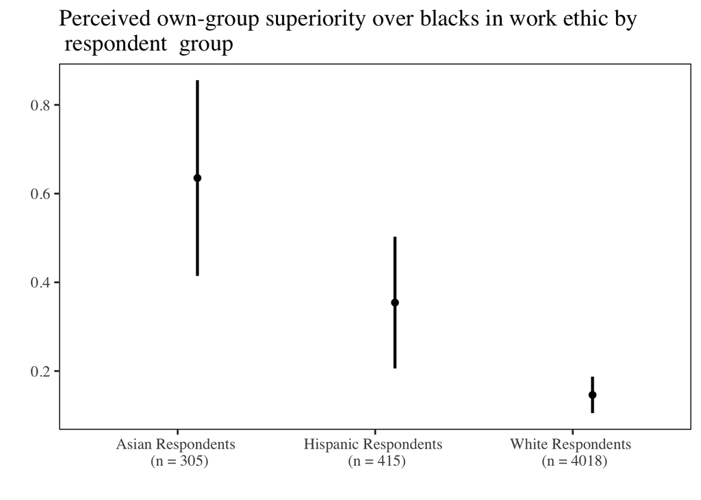

### Intelligence

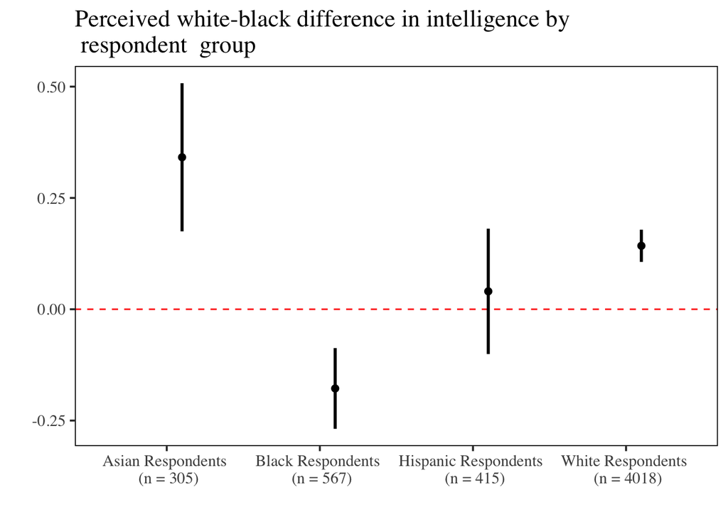

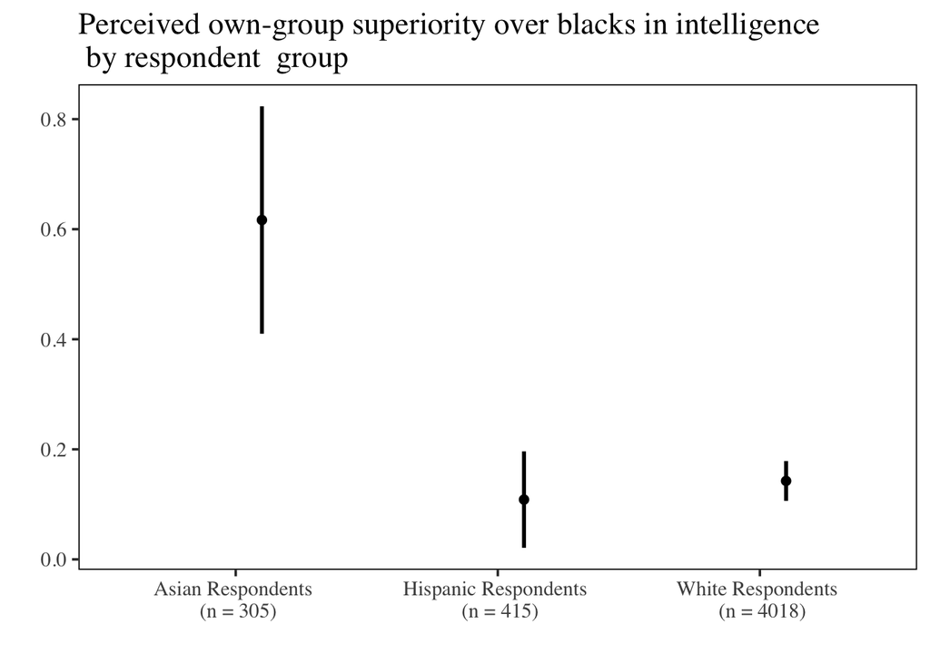

### Trustworthiness

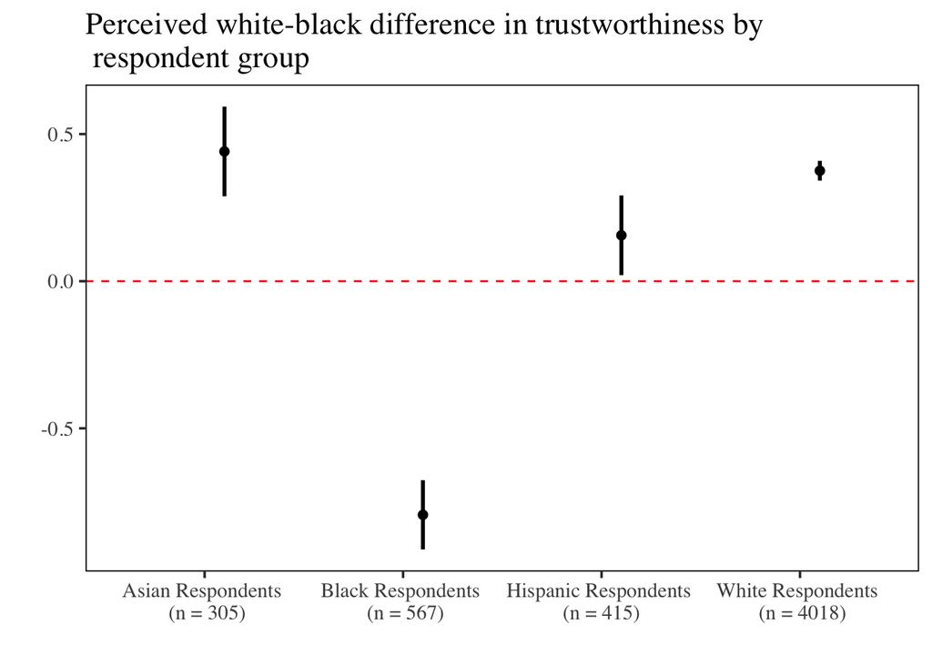

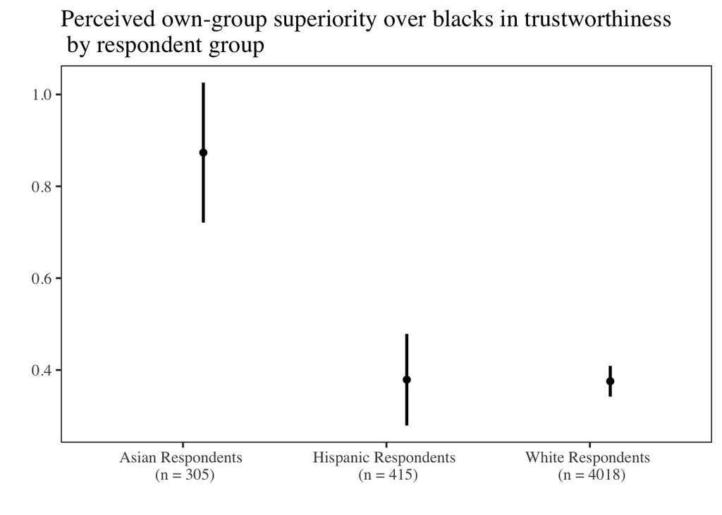

### Aggression

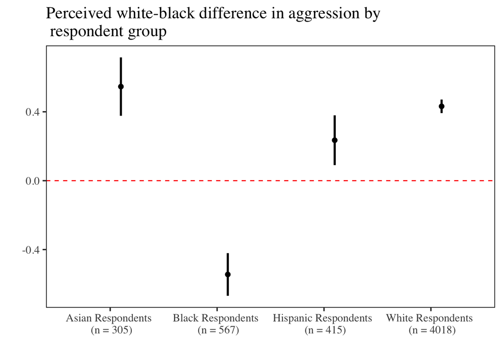

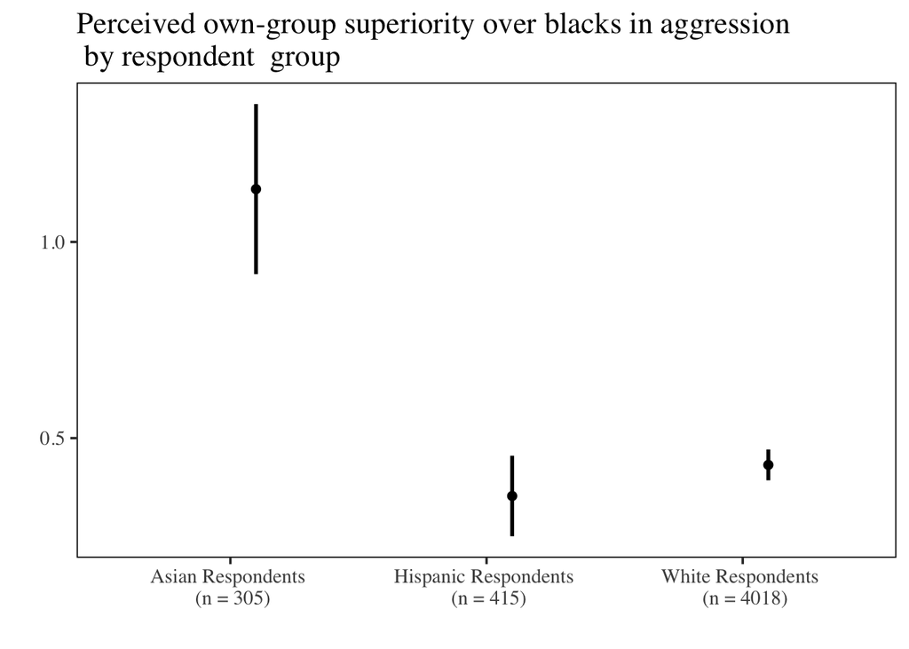